# Map Visualizations and Neighorhood Change

Prof. Anthony Howell

# Part 1: How not to lie with choropleth maps

## Grab Census Data (review from Lab 2)

- Using `tidycensus`, load in variables on median household income and median housing value from the `acs5` 2013-2017.

```r
library(tidycensus)
library(tidyverse)
library(viridis)
library(plyr)
library(gtools)
```

```r
census_api_key("Your Key here")
```

```r
Var <- c("B19013_001","B25077_001")
## c(Median household Income, Median Housing Value)

CenDF <- get_acs(geography = "county",
                   variables = Var,
                   year = 2017,
                   survey = "acs5",
                   geometry = TRUE,
                   shift_geo = TRUE)
```

## Manipulate Data

- Create new variable for the housing price to income ratio.

```r
CenDF <-
  CenDF %>%
    mutate(variable=case_when(
      variable=="B19013_001" ~ "HHIncome",
      variable=="B25077_001" ~ "HouseValue")) %>%
    select(-moe) %>%
    spread(variable, estimate) %>%  #Spread moves rows into columns
    mutate(HHInc_HousePrice_Ratio=round(HouseValue/HHIncome,2))
```

## Map Data

- Rely on ggplot and `scale_fill_viridis` to create natural breaks for color sequencing and to mapHouse-Price-to-Income Ratio

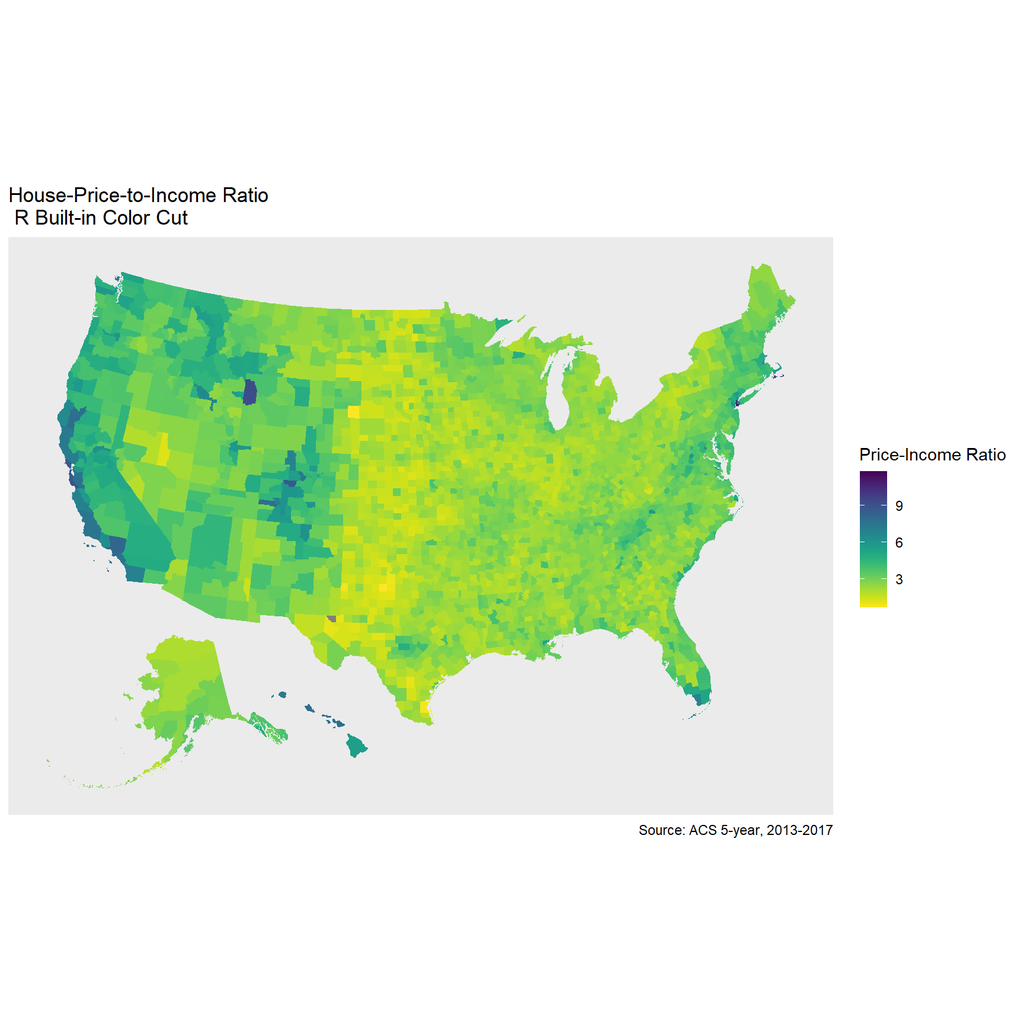

```r
Plot1 <-  ggplot(CenDF) +
    geom_sf(aes(fill = HHInc_HousePrice_Ratio), color=NA) +
    coord_sf(datum=NA) +
    labs(title = "House-Price-to-Income Ratio \n R Built-in Color Cut",
         caption = "Source: ACS 5-year, 2013-2017",
         fill = "Price-Income Ratio") +
    scale_fill_viridis(direction=-1)
Plot1
```

## Color Scales in R

R has a variety of functions that allow the user to create color scales easily. These functions generally require you to specify a color on each end of the spectrum and they will interpolate the values between based upon how many levels you desire.

## Importance

We select colors to communicate information about our data. If we are using a continuous variable the most basic decision is whether we want to represent it as positive and negative deviations from the average (a divergent scale), or as a continuum of low to high values (a sequential scale). If we have categorical data, it is generally visualized through different colors representing each group (a qualitative scale).

## Color Schemes

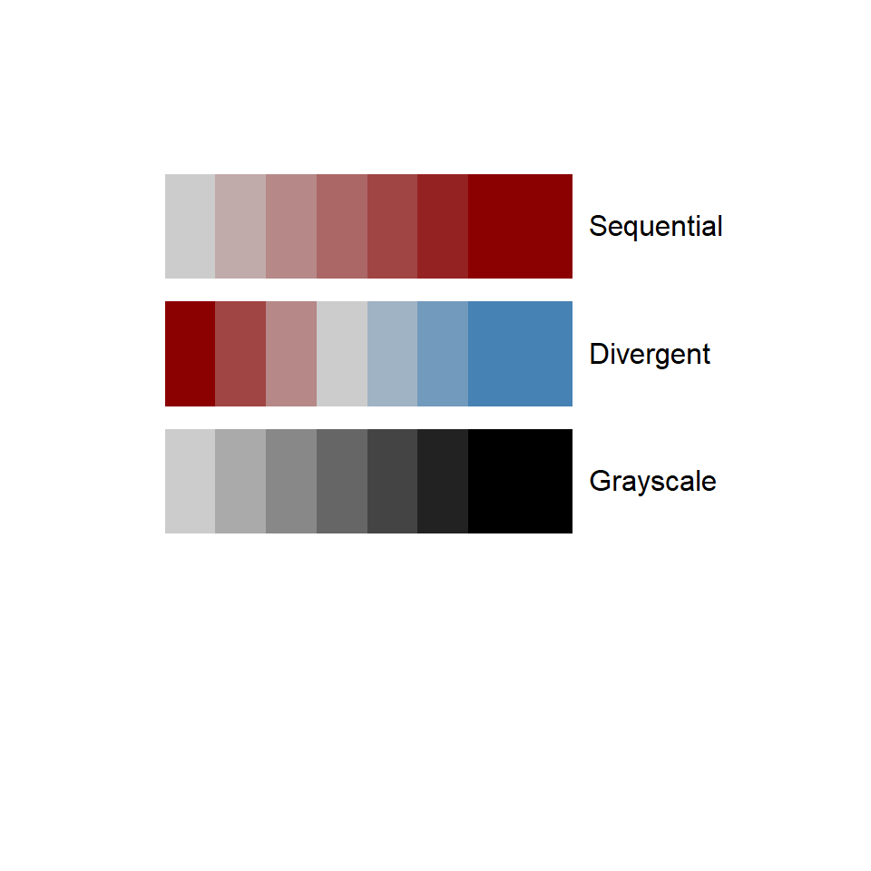

```r
plot( 1:7, rep(1,7), ylim=c(-0.5,3.5), xlim=c(0,12), yaxt="n", xaxt="n", bty="n", xlab="", ylab=""  )

color.function <- colorRampPalette( c("gray80","darkred") )
col.ramp <- color.function( 7 ) # number of groups you desire
points( 1:7, rep(3,7), pch=15, cex=8, col=col.ramp )

color.function <- colorRampPalette( c("darkred","gray80","steelblue") )
col.ramp <- color.function( 7 ) # number of groups you desire
points( 1:7, rep(2,7), pch=15, cex=8, col=col.ramp )

color.function <- colorRampPalette( c("gray80","black") )
col.ramp <- color.function( 7 ) # number of groups you desire
points( 1:7, rep(1,7), pch=15, cex=8, col=col.ramp )

text( 8, 3, "Sequential", pos=4 )
text( 8, 2, "Divergent", pos=4 )
text( 8, 1, "Grayscale", pos=4 )
```

## Alternative Map: 2 Color Groups

- Transform `HHInc_HousePrice_Ratio` from continuous variable to factor variable with 2 levels

```r
## Convert Integer into factor variable
CenDF$fill_factor <- quantcut(CenDF$HHInc_HousePrice_Ratio, q = seq(0, 1, by = 0.5))
CenDF$fill_factor = mapvalues(CenDF$fill_factor, from = levels(CenDF$fill_factor),
                        to = c("low","high"))


## Assign 2 colors
col.ramp <- viridis(n = 2) # number of groups you desire
```

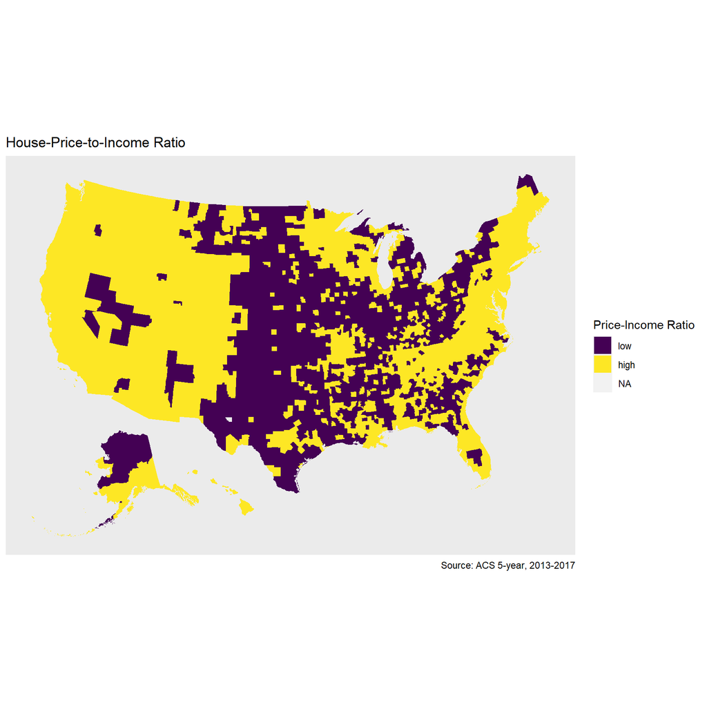

```r
Plot2<-ggplot(CenDF) +
  geom_sf(aes(fill = fill_factor), color=NA) +
  coord_sf(datum=NA) +
  labs(title = "House-Price-to-Income Ratio",
       caption = "Source: ACS 5-year, 2013-2017",
       fill = "Price-Income Ratio") +
  scale_fill_manual("Price-Income Ratio",values =  col.ramp)
Plot2
```

## Terciles - 3 Color Groups

- Transform `HHInc_HousePrice_Ratio` from continuous variable to factor variable with 3 levels

```r
## Convert Integer into factor variable
CenDF$fill_factor <- quantcut(CenDF$HHInc_HousePrice_Ratio, q = seq(0, 1, by = .33))
CenDF$fill_factor = mapvalues(CenDF$fill_factor, from = levels(CenDF$fill_factor),
                        to = c("low","med", "high"))


## Assign 3 colors
col.ramp <- viridis(n = 3) # number of groups you desire
```

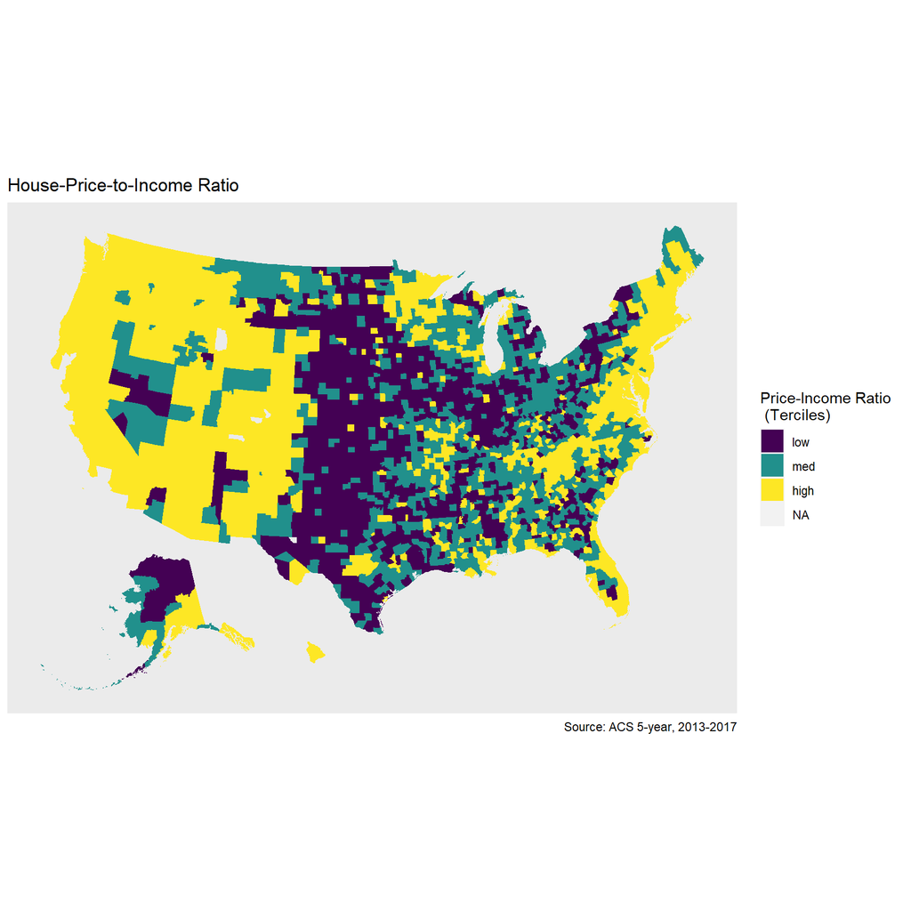

```r
Plot3<-ggplot(CenDF) +
  geom_sf(aes(fill = fill_factor), color=NA) +
  coord_sf(datum=NA) +
  labs(title = "House-Price-to-Income Ratio",
       caption = "Source: ACS 5-year, 2013-2017",
       fill = "Price-Income Ratio") +
  scale_fill_manual("Price-Income Ratio \n (Terciles)",values =  col.ramp)
Plot3
```

## Quintiles - 5 Color Groups

- Transform `HHInc_HousePrice_Ratio` from continuous variable to factor variable with 5 levels

```r
## Convert Integer into factor variable
CenDF$fill_factor <- quantcut(CenDF$HHInc_HousePrice_Ratio, q = seq(0, 1, by = .2))
CenDF$fill_factor = mapvalues(CenDF$fill_factor, from = levels(CenDF$fill_factor),
                        to = c("1","2","3", "4","5"))


## Assign 5 colors
col.ramp <- viridis(n = 5) # number of groups you desire
```

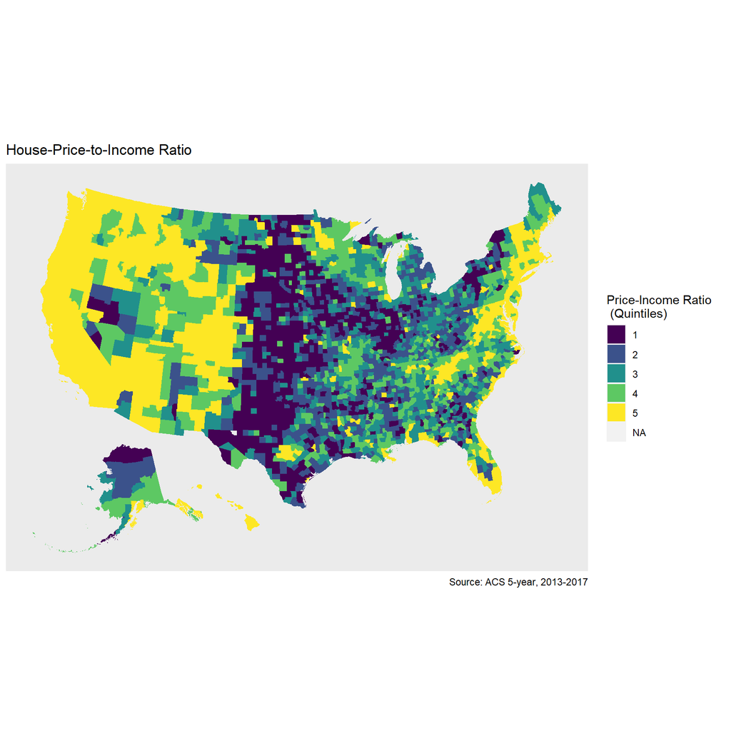

```r
Plot4<-ggplot(CenDF) +
  geom_sf(aes(fill = fill_factor), color=NA) +
  coord_sf(datum=NA) +
  labs(title = "House-Price-to-Income Ratio",
       caption = "Source: ACS 5-year, 2013-2017",
       fill = "Price-Income Ratio") +
  scale_fill_manual("Price-Income Ratio  \n (Quintiles)",values =  col.ramp)
Plot4
```

## Unequal Intervals

- Transform `HHInc_HousePrice_Ratio` from continuous variable to factor variable with 6 levels

```r
## Convert Integer into factor variable
CenDF$fill_factor <- quantcut(CenDF$HHInc_HousePrice_Ratio, q = c(0,.1,.25,.5,.75,.9,1))
#CenDF$fill_factor = mapvalues(CenDF$fill_factor, from = levels(CenDF$fill_factor),
 #                       to = c("< .1",".1-.25",".25-.5", ".5-.75",".75-.9","> .9"))


## Assign 6 colors
col.ramp <- viridis(n = 6) # number of groups you desire
```

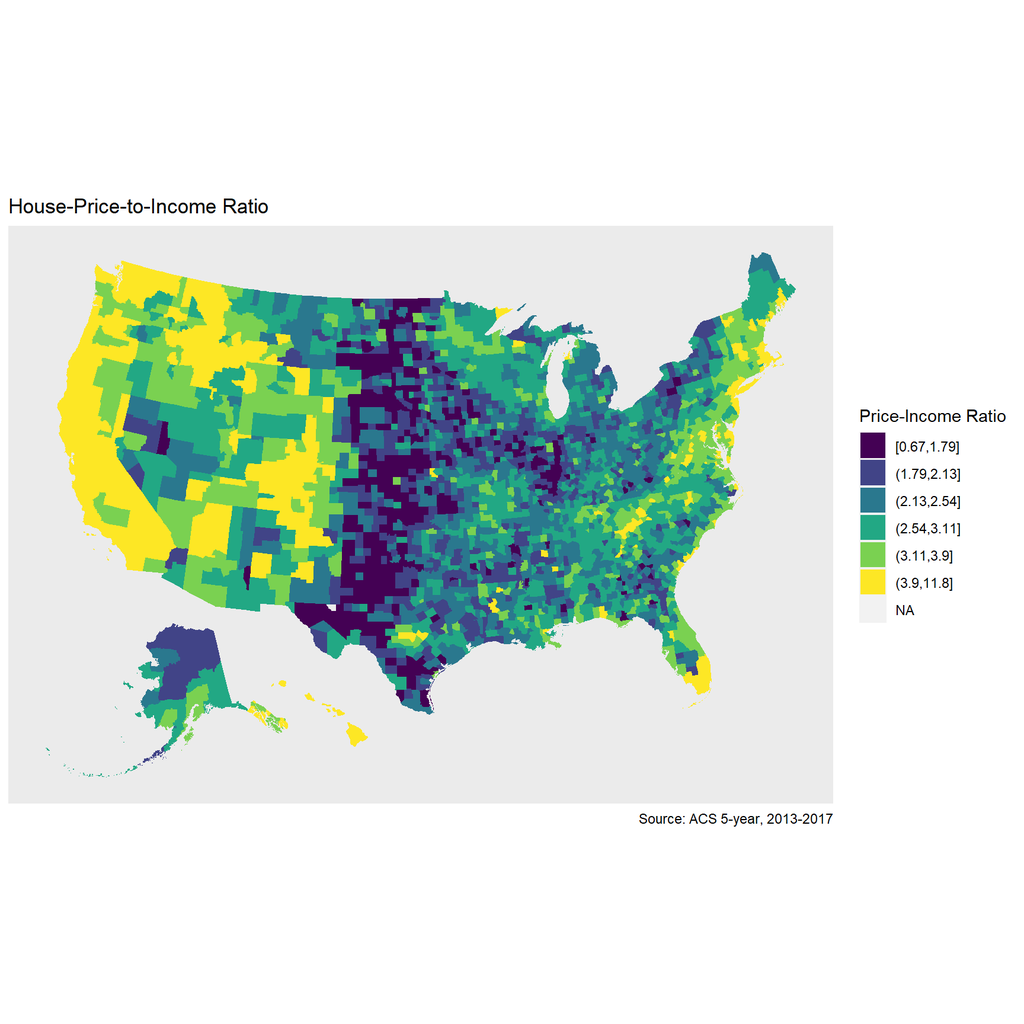

```r
Plot5<-ggplot(CenDF) +
  geom_sf(aes(fill = fill_factor), color=NA) +
  coord_sf(datum=NA) +
  labs(title = "House-Price-to-Income Ratio",
       caption = "Source: ACS 5-year, 2013-2017",
       fill = "Price-Income Ratio") +
  scale_fill_manual("Price-Income Ratio",values =  col.ramp)
Plot5
```

## Compare Maps

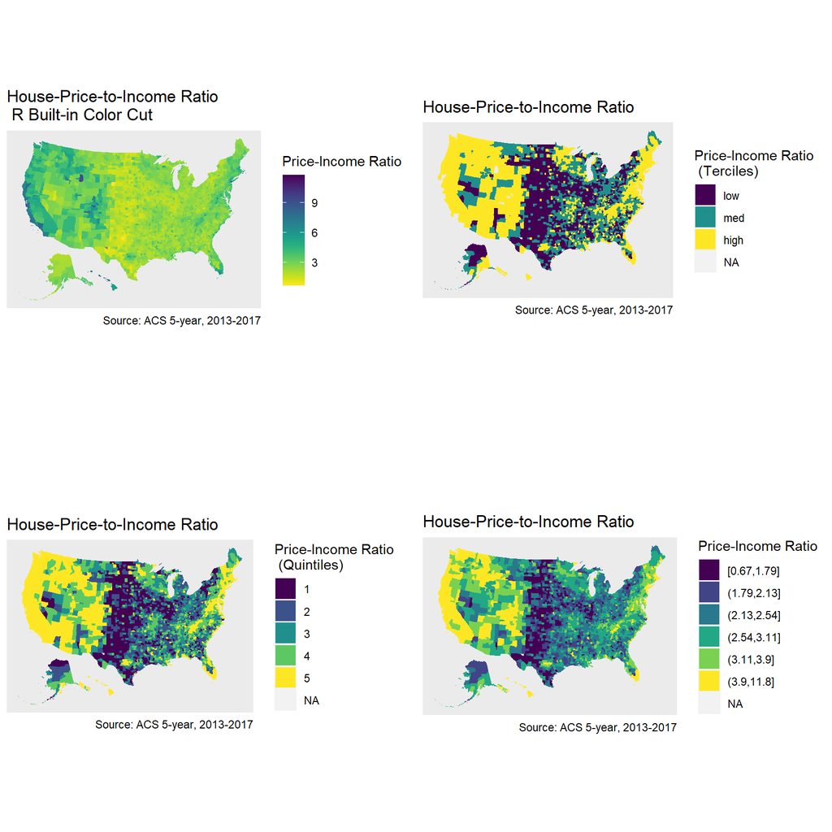

```r
library(gridExtra)
grid.arrange(Plot1,Plot3,Plot4,Plot5, nrow=2)
```